# Sarcasm/irony project

2025-05-27

**Trial probe: Approve**

**Statistical Analysis**

This section contains the analysis for the trial probe “approve”. First, the total proportion of responses (“no” coded as 1 or “yes” coded as 2) was compared as a function of intonation type (sarcastic or declarative). Next, the proportions of responses were compared according to the second predictor alone, “modifier_type” (3 levels: +gradable +subjective +valence adjectives, +gradable +subjective –valence adjective, –gradable –subjective adjectives/nouns). Finally, both predictors are visualized and considered in tandem as they relate to the responses of “yes” or “no”.

In each case, a Bayesian multilevel logistic regression was run in which the binary outcome (log-odds of choosing “yes”) was analyzed as a function of the relevant predictors (detailed below) and a random intercept for subject id, trial object, and trial modifier. Each model was estimated using MCMC sampling with 4 chains of 2000 iterations and a warmup of 1000 distributed between 6 processing cores. Next, additional models were run to compare groups for intonation only and modifier type only.

**Intonation only**

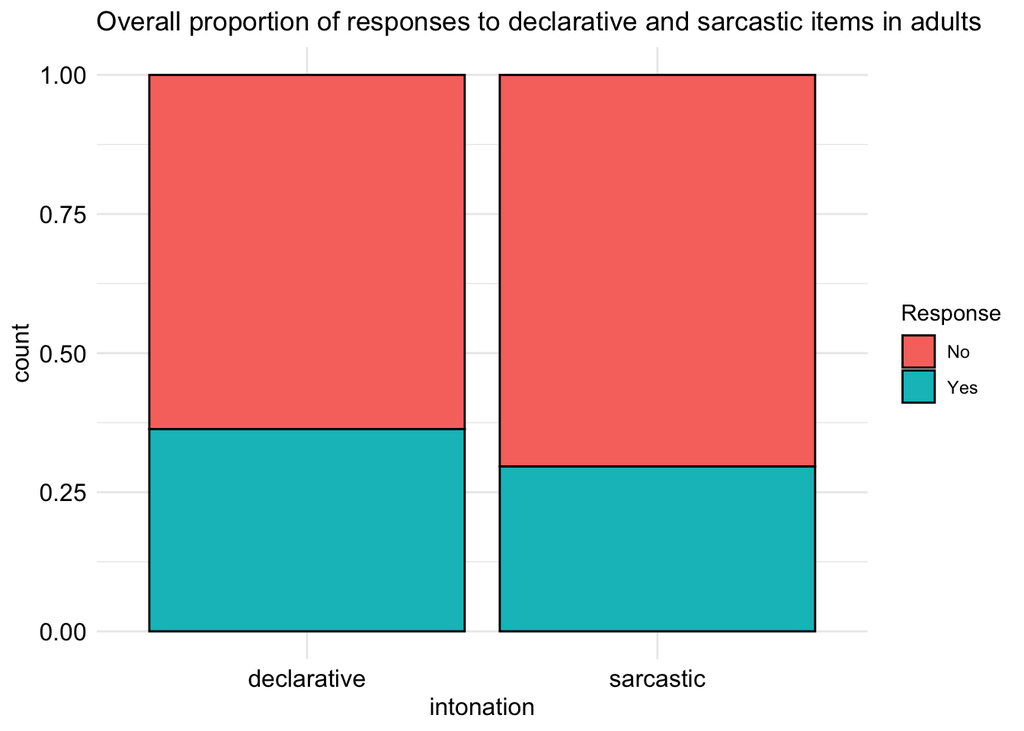

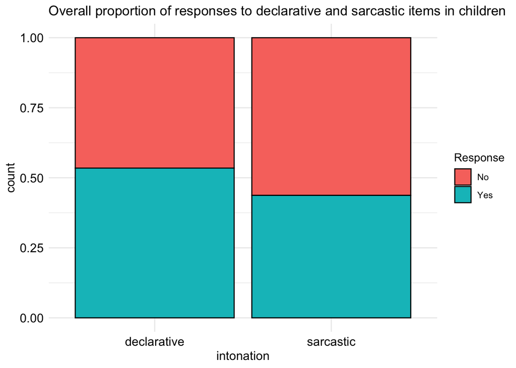

**Adult model for approve with intonation only**

| Parameter | Median | Mean | MAP | CI | CI_low | CI_high | pd | ps | Rhat | ESS |
| --- | --- | --- | --- | --- | --- | --- | --- | --- | --- | --- |
| b_Intercept | -0.909 | -0.904 | -0.932 | 0.95 | -1.652 | -0.102 | 0.987 | 0.959 | 1.013 | 435.018 |
| b_intonationsarcastic | -0.644 | -0.639 | -0.660 | 0.95 | -0.935 | -0.344 | 1.000 | 0.999 | 1.000 | 4106.671 |

**Child model for approve with intonation only**

| Parameter | Median | Mean | MAP | CI | CI_low | CI_high | pd | ps | Rhat | ESS |
| --- | --- | --- | --- | --- | --- | --- | --- | --- | --- | --- |
| b_Intercept | 0.357 | 0.372 | 0.265 | 0.95 | -0.506 | 1.302 | 0.791 | 0.656 | 1.005 | 803.090 |
| b_intonationsarcastic | -0.734 | -0.735 | -0.709 | 0.95 | -1.162 | -0.327 | 1.000 | 0.995 | 1.000 | 5437.441 |

**Comparison Model for approve and for intonation only**

| Parameter | Median | Mean | MAP | CI | CI_low | CI_high | pd | ps | Rhat | ESS |
| --- | --- | --- | --- | --- | --- | --- | --- | --- | --- | --- |
| b_Intercept | -0.921 | -0.923 | -0.913 | 0.95 | -1.736 | -0.133 | 0.986 | 0.968 | 1.002 | 763.124 |
| b_intonationsarcastic | -0.638 | -0.637 | -0.654 | 0.95 | -0.930 | -0.350 | 1.000 | 1.000 | 1.000 | 7174.825 |
| b_groupchildren | -29.863 | -48.002 | -11.987 | 0.95 | -186.983 | -8.072 | 1.000 | 1.000 | 1.035 | 220.668 |
| b_intonationsarcastic:groupchildren | -2.151 | -22.626 | 0.123 | 0.95 | -310.115 | 104.063 | 0.538 | 0.534 | 1.058 | 123.856 |

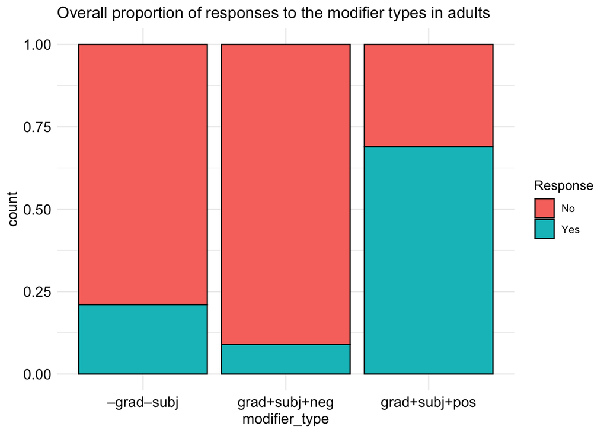

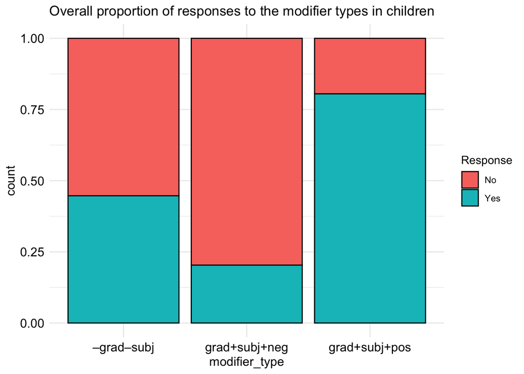

**Adult model for approve for modifier type only**

| Parameter | Median | Mean | MAP | CI | CI_low | CI_high | pd | ps | Rhat | ESS |
| --- | --- | --- | --- | --- | --- | --- | --- | --- | --- | --- |
| b_Intercept | -1.716 | -1.713 | -1.726 | 0.95 | -2.281 | -1.146 | 1 | 1 | 1.001 | 1992.504 |
| b_modifier_typegradPsubjPneg | -1.333 | -1.348 | -1.287 | 0.95 | -2.161 | -0.606 | 1 | 1 | 1.001 | 2363.620 |
| b_modifier_typegradPsubjPpos | 2.763 | 2.765 | 2.774 | 0.95 | 2.069 | 3.476 | 1 | 1 | 1.001 | 1496.593 |

**Child model for approve for modifier type only**

| Parameter | Median | Mean | MAP | CI | CI_low | CI_high | pd | ps | Rhat | ESS |
| --- | --- | --- | --- | --- | --- | --- | --- | --- | --- | --- |
| b_Intercept | -0.283 | -0.292 | -0.219 | 0.95 | -1.202 | 0.606 | 0.740 | 0.585 | 1.014 | 1011.773 |
| b_modifier_typegradPsubjPneg | -1.683 | -1.677 | -1.690 | 0.95 | -2.925 | -0.450 | 0.995 | 0.991 | 1.008 | 1155.548 |
| b_modifier_typegradPsubjPpos | 2.462 | 2.470 | 2.446 | 0.95 | 1.202 | 3.786 | 1.000 | 1.000 | 1.007 | 1016.074 |

**Comparison Model for approve and for modifier type only**

| Parameter | Median | Mean | MAP | CI | CI_low | CI_high | pd | ps | Rhat | ESS |
| --- | --- | --- | --- | --- | --- | --- | --- | --- | --- | --- |
| b_Intercept | -1.726 | -1.722 | -1.753 | 0.95 | -2.329 | -1.132 | 1.000 | 1.000 | 1.012 | 234.942 |
| b_modifier_typegradPsubjPneg | -1.351 | -1.344 | -1.365 | 0.95 | -2.143 | -0.563 | 0.999 | 0.998 | 1.006 | 248.609 |
| b_modifier_typegradPsubjPpos | 2.783 | 2.778 | 2.812 | 0.95 | 2.012 | 3.516 | 1.000 | 1.000 | 1.011 | 238.750 |
| b_groupchildren | -109.899 | -468.442 | -18.967 | 0.95 | -2497.809 | -6.465 | 1.000 | 1.000 | 1.513 | 4.903 |
| b_modifier_typegradPsubjPneg:groupchildren | -107.170 | -903.008 | -12.760 | 0.95 | -6638.251 | 519.085 | 0.729 | 0.729 | 1.398 | 11.152 |
| b_modifier_typegradPsubjPpos:groupchildren | 37.873 | 266.314 | -1.325 | 0.95 | -729.406 | 2092.575 | 0.665 | 0.664 | 1.538 | 4.526 |

**Adults: approve**

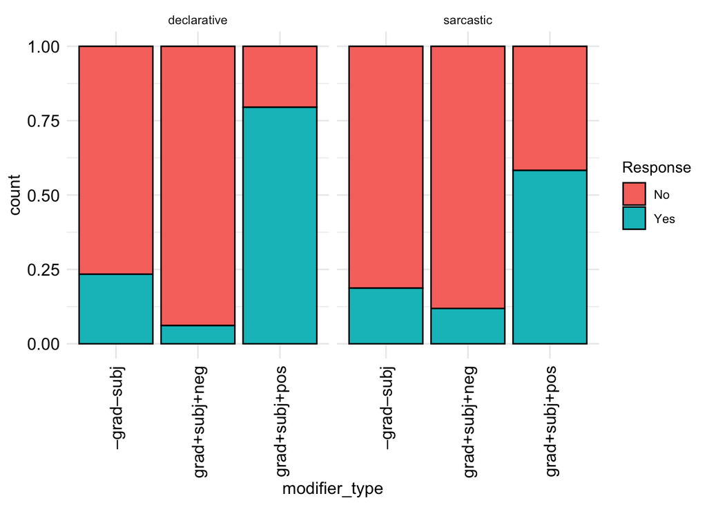

**Children: approve**

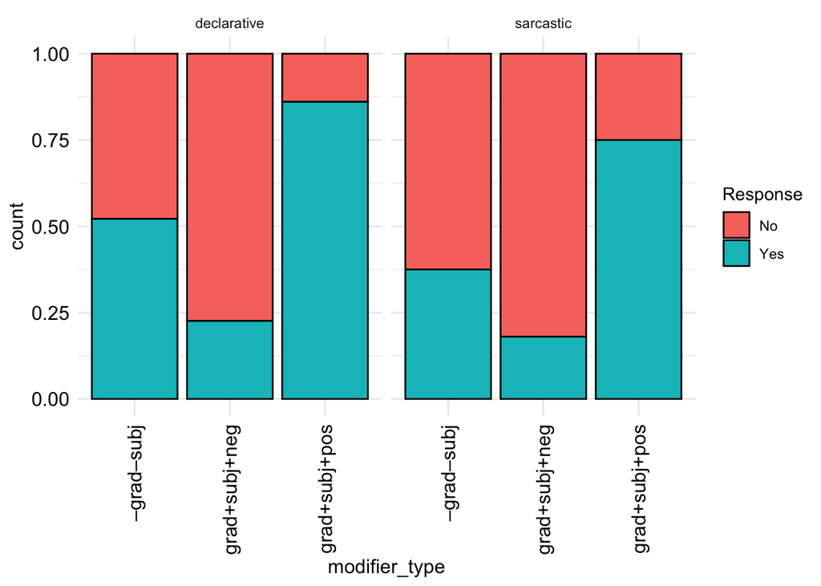

**Adult model for approve for both intonation and modifier type**

| Parameter | Median | Mean | MAP | CI | CI_low | CI_high | pd | ps | Rhat | ESS |
| --- | --- | --- | --- | --- | --- | --- | --- | --- | --- | --- |
| b_Intercept | -1.561 | -1.560 | -1.577 | 0.95 | -2.206 | -0.931 | 1.000 | 1.000 | 1.003 | 2399.796 |
| b_intonationsarcastic | -0.424 | -0.425 | -0.414 | 0.95 | -0.910 | 0.056 | 0.956 | 0.842 | 1.000 | 3917.525 |
| b_modifier_typegradPsubjPneg | -2.070 | -2.075 | -2.161 | 0.95 | -3.053 | -1.150 | 1.000 | 1.000 | 1.001 | 2817.179 |
| b_modifier_typegradPsubjPpos | 3.427 | 3.439 | 3.388 | 0.95 | 2.636 | 4.304 | 1.000 | 1.000 | 1.001 | 2546.460 |
| b_intonationsarcastic:modifier_typegradPsubjPneg | 1.292 | 1.296 | 1.164 | 0.95 | 0.450 | 2.149 | 0.999 | 0.996 | 1.001 | 4378.395 |
| b_intonationsarcastic:modifier_typegradPsubjPpos | -1.019 | -1.015 | -1.081 | 0.95 | -1.680 | -0.366 | 0.999 | 0.997 | 1.000 | 4657.255 |

**Child model for approve for both intonation and modifier type**

| Parameter | Median | Mean | MAP | CI | CI_low | CI_high | pd | ps | Rhat | ESS |
| --- | --- | --- | --- | --- | --- | --- | --- | --- | --- | --- |
| b_Intercept | 0.132 | 0.128 | 0.141 | 0.95 | -0.852 | 1.126 | 0.601 | 0.457 | 1.000 | 1997.061 |
| b_intonationsarcastic | -0.773 | -0.771 | -0.782 | 0.95 | -1.377 | -0.145 | 0.991 | 0.968 | 1.000 | 3986.028 |
| b_modifier_typegradPsubjPneg | -1.940 | -1.945 | -1.957 | 0.95 | -3.409 | -0.571 | 0.997 | 0.994 | 1.000 | 2180.233 |
| b_modifier_typegradPsubjPpos | 2.693 | 2.726 | 2.618 | 0.95 | 1.355 | 4.195 | 1.000 | 1.000 | 1.000 | 2376.359 |
| b_intonationsarcastic:modifier_typegradPsubjPneg | 0.317 | 0.314 | 0.305 | 0.95 | -0.674 | 1.286 | 0.741 | 0.614 | 0.999 | 4210.585 |
| b_intonationsarcastic:modifier_typegradPsubjPpos | -0.312 | -0.309 | -0.342 | 0.95 | -1.369 | 0.702 | 0.723 | 0.594 | 1.000 | 4422.501 |

**Trial probe: Mean**

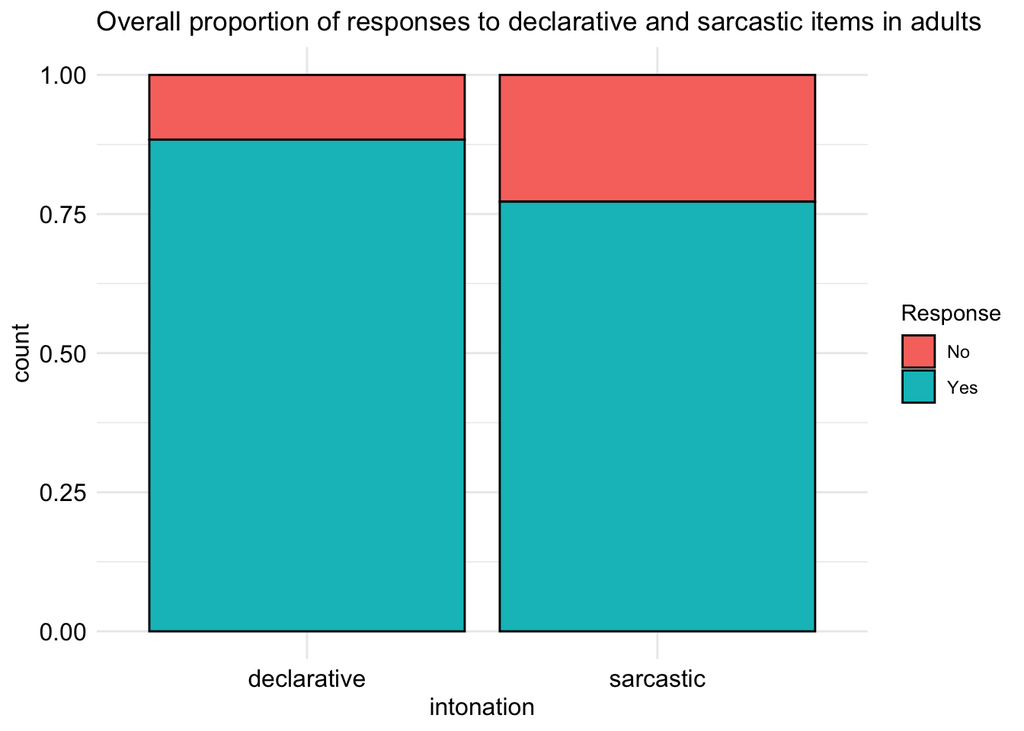

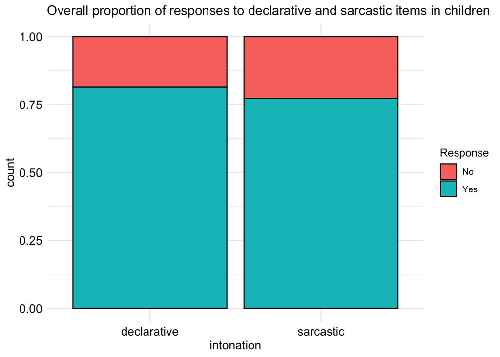

**Adult model for mean with intonation only**

| Parameter | Median | Mean | MAP | CI | CI_low | CI_high | pd | ps | Rhat | ESS |
| --- | --- | --- | --- | --- | --- | --- | --- | --- | --- | --- |
| b_Intercept | 2.545 | 2.550 | 2.547 | 0.95 | 2.146 | 2.981 | 1 | 1 | 1.003 | 2139.771 |
| b_intonationsarcastic | -0.994 | -0.998 | -0.984 | 0.95 | -1.305 | -0.709 | 1 | 1 | 1.000 | 4652.238 |

**Child model for mean with intonation only**

[output not shown]

[output not shown]

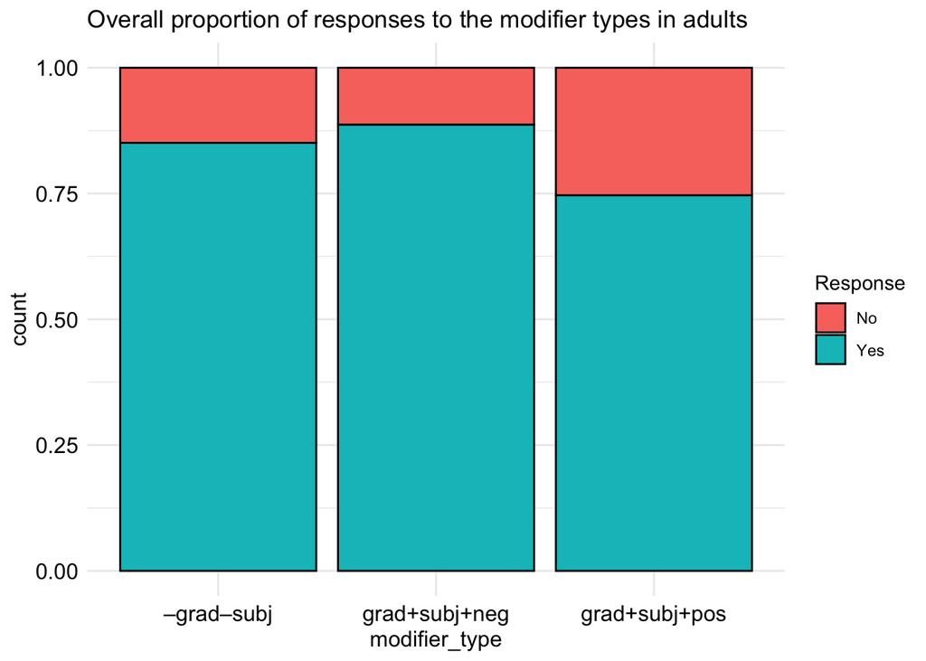

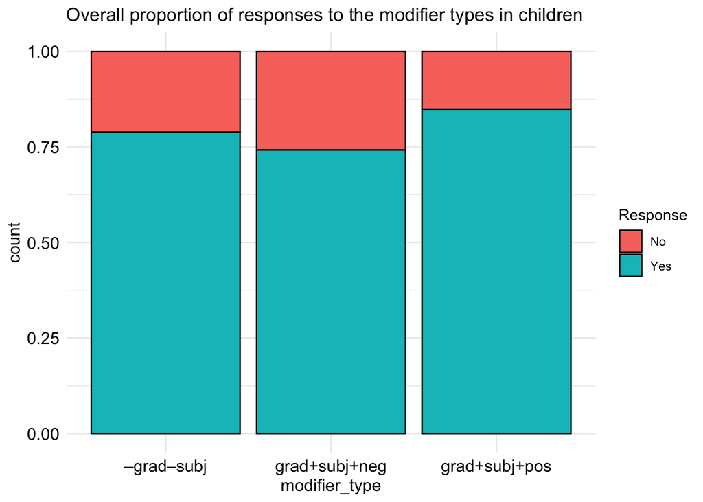

**Adult model for mean with modifier type only**

| Parameter | Median | Mean | MAP | CI | CI_low | CI_high | pd | ps | Rhat | ESS |
| --- | --- | --- | --- | --- | --- | --- | --- | --- | --- | --- |
| b_Intercept | 2.067 | 2.071 | 2.046 | 0.95 | 1.643 | 2.507 | 1.000 | 1.000 | 1 | 2926.169 |
| b_modifier_typegradPsubjPneg | 0.389 | 0.387 | 0.457 | 0.95 | -0.091 | 0.878 | 0.945 | 0.804 | 1 | 3459.805 |
| b_modifier_typegradPsubjPpos | -0.750 | -0.749 | -0.745 | 0.95 | -1.191 | -0.302 | 0.999 | 0.992 | 1 | 3295.455 |

**Child model for mean with modifier type only**

| Parameter | Median | Mean | MAP | CI | CI_low | CI_high | pd | ps | Rhat | ESS |
| --- | --- | --- | --- | --- | --- | --- | --- | --- | --- | --- |
| b_Intercept | 2.324 | 2.346 | 2.315 | 0.95 | 1.443 | 3.380 | 1.000 | 1.000 | 1.001 | 1365.171 |
| b_modifier_typegradPsubjPneg | -0.397 | -0.394 | -0.422 | 0.95 | -0.991 | 0.209 | 0.902 | 0.761 | 0.999 | 4280.799 |
| b_modifier_typegradPsubjPpos | 0.712 | 0.714 | 0.674 | 0.95 | 0.061 | 1.374 | 0.983 | 0.942 | 1.000 | 4427.149 |

**Comparison model for mean with modifier type only**

| Parameter | Median | Mean | MAP | CI | CI_low | CI_high | pd | ps | Rhat | ESS |
| --- | --- | --- | --- | --- | --- | --- | --- | --- | --- | --- |
| b_Intercept | 2.053 | 2.061 | 1.993 | 0.95 | 1.680 | 2.466 | 1.000 | 1.000 | 1.018 | 323.614 |
| b_modifier_typegradPsubjPneg | 0.402 | 0.419 | 0.346 | 0.95 | -0.003 | 0.905 | 0.975 | 0.847 | 1.022 | 123.020 |
| b_modifier_typegradPsubjPpos | -0.715 | -0.714 | -0.708 | 0.95 | -1.134 | -0.271 | 0.999 | 0.989 | 1.027 | 181.774 |
| b_groupchildren | -39.280 | -72.584 | -13.263 | 0.95 | -339.222 | -9.203 | 1.000 | 1.000 | 1.032 | 171.914 |
| b_modifier_typegradPsubjPneg:groupchildren | 1.651 | 9.860 | -1.468 | 0.95 | -159.493 | 239.061 | 0.522 | 0.519 | 1.028 | 289.862 |
| b_modifier_typegradPsubjPpos:groupchildren | 2.867 | 0.073 | 2.265 | 0.95 | -295.563 | 208.566 | 0.536 | 0.533 | 1.009 | 282.344 |

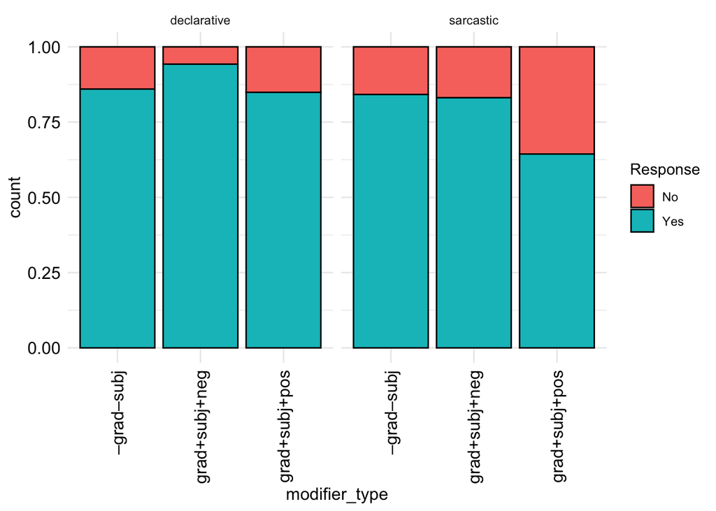

**Adult model for mean with Intonation and Modifier type**

| Parameter | Median | Mean | MAP | CI | CI_low | CI_high | pd | ps | Rhat | ESS |
| --- | --- | --- | --- | --- | --- | --- | --- | --- | --- | --- |
| b_Intercept | 2.214 | 2.221 | 2.233 | 0.95 | 1.715 | 2.773 | 1.000 | 1.000 | 1.003 | 1335.634 |
| b_intonationsarcastic | -0.160 | -0.162 | -0.143 | 0.95 | -0.663 | 0.356 | 0.730 | 0.470 | 1.003 | 1977.960 |
| b_modifier_typegradPsubjPneg | 1.188 | 1.194 | 1.177 | 0.95 | 0.479 | 1.966 | 1.000 | 0.998 | 1.000 | 2007.261 |
| b_modifier_typegradPsubjPpos | -0.055 | -0.056 | -0.071 | 0.95 | -0.678 | 0.548 | 0.573 | 0.335 | 1.000 | 2173.966 |
| b_intonationsarcastic:modifier_typegradPsubjPneg | -1.260 | -1.273 | -1.206 | 0.95 | -2.124 | -0.490 | 1.000 | 0.995 | 1.001 | 2163.393 |
| b_intonationsarcastic:modifier_typegradPsubjPpos | -1.242 | -1.240 | -1.224 | 0.95 | -1.927 | -0.542 | 1.000 | 1.000 | 1.001 | 2055.112 |

**Child model for mean with Intonation and Modifier type**

| Parameter | Median | Mean | MAP | CI | CI_low | CI_high | pd | ps | Rhat | ESS |
| --- | --- | --- | --- | --- | --- | --- | --- | --- | --- | --- |
| b_Intercept | 2.308 | 2.340 | 2.291 | 0.95 | 1.374 | 3.466 | 1.000 | 1.000 | 1.002 | 1448.930 |
| b_intonationsarcastic | 0.041 | 0.043 | -0.003 | 0.95 | -0.735 | 0.812 | 0.541 | 0.370 | 1.000 | 3168.485 |
| b_modifier_typegradPsubjPneg | 0.057 | 0.061 | 0.064 | 0.95 | -0.771 | 0.902 | 0.559 | 0.378 | 1.001 | 3318.822 |
| b_modifier_typegradPsubjPpos | 0.904 | 0.909 | 0.847 | 0.95 | -0.002 | 1.877 | 0.975 | 0.939 | 1.001 | 3426.247 |
| b_intonationsarcastic:modifier_typegradPsubjPneg | -0.891 | -0.896 | -0.899 | 0.95 | -1.975 | 0.167 | 0.952 | 0.907 | 1.001 | 3175.973 |
| b_intonationsarcastic:modifier_typegradPsubjPpos | -0.340 | -0.334 | -0.330 | 0.95 | -1.480 | 0.875 | 0.699 | 0.600 | 1.000 | 3204.649 |

**Trial probe: Nice**

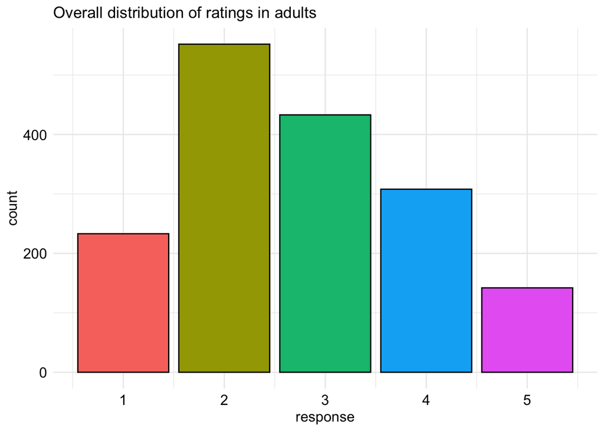

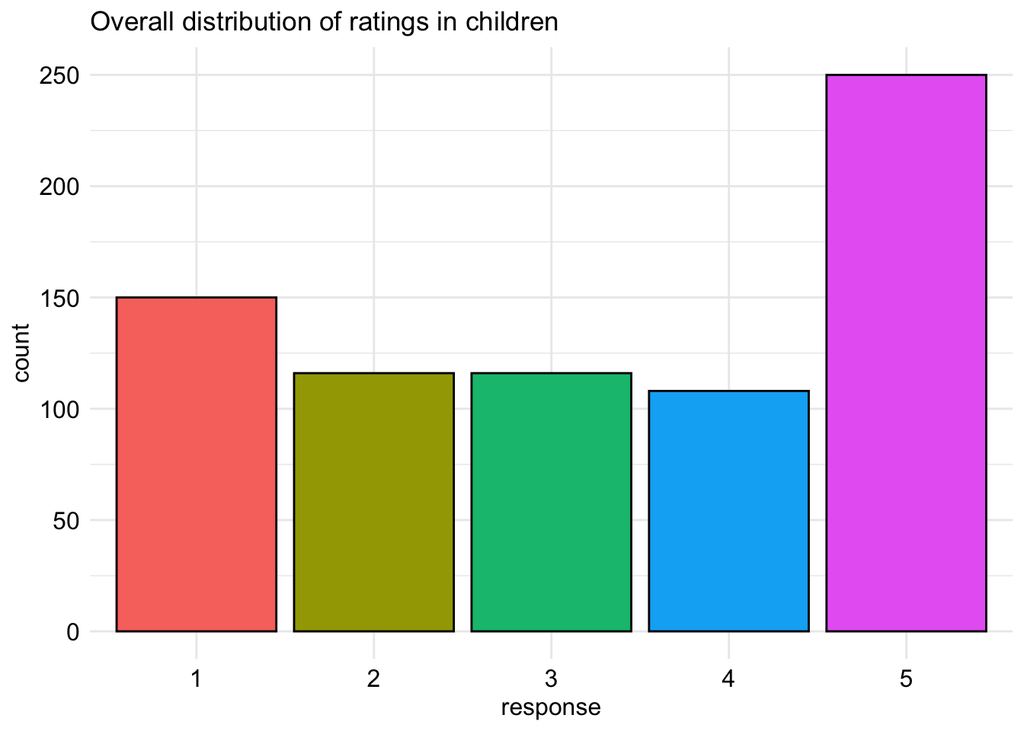

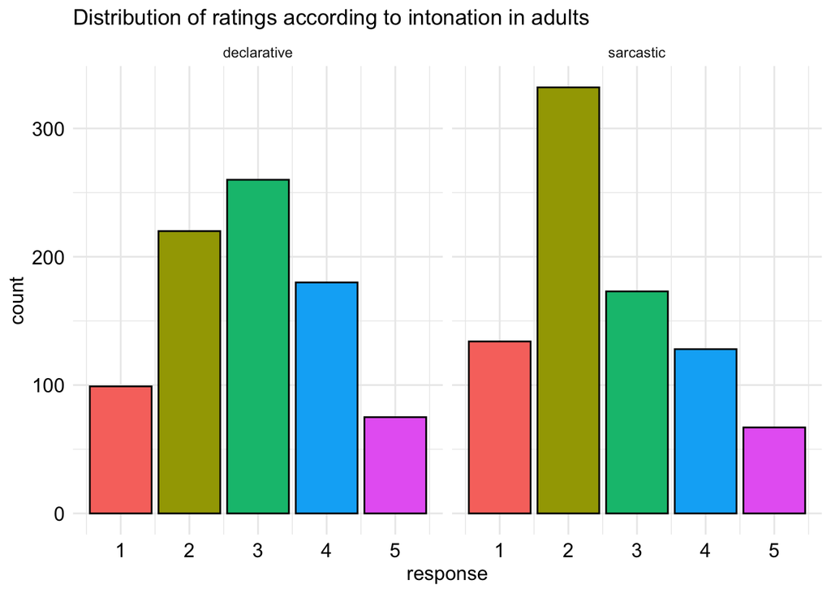

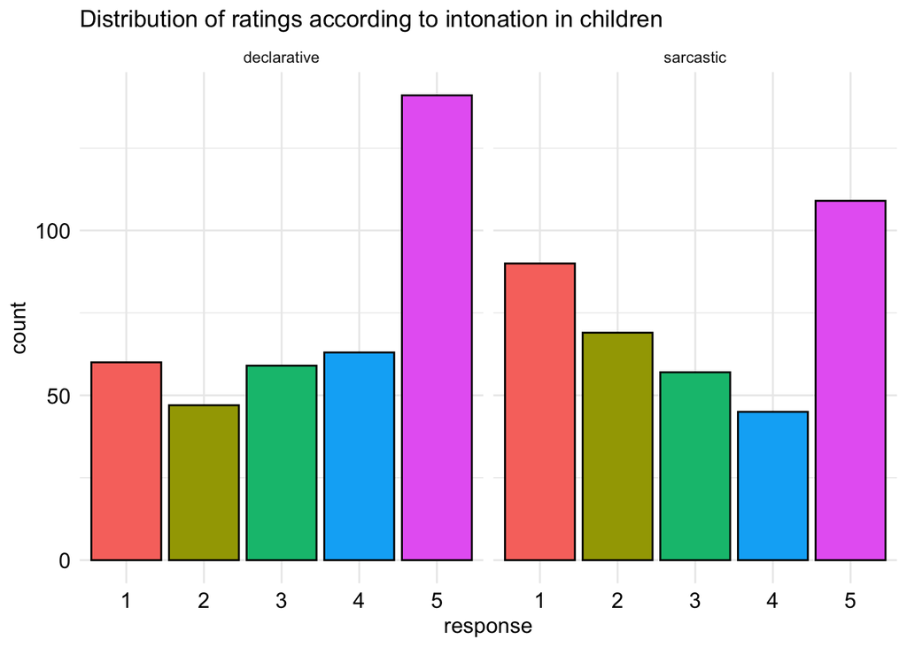

**Adult model for nice and intonation only**

| Parameter | Median | Mean | MAP | CI | CI_low | CI_high | pd | ps | Rhat | ESS |
| --- | --- | --- | --- | --- | --- | --- | --- | --- | --- | --- |
| b_Intercept[1] | -3.182 | -3.195 | -3.164 | 0.95 | -3.926 | -2.525 | 1.000 | 1.000 | 1.004 | 391.660 |
| b_Intercept[2] | -0.609 | -0.619 | -0.543 | 0.95 | -1.344 | 0.055 | 0.964 | 0.911 | 1.005 | 400.568 |
| b_Intercept[3] | 1.205 | 1.200 | 1.201 | 0.95 | 0.477 | 1.882 | 1.000 | 0.998 | 1.004 | 394.135 |
| b_Intercept[4] | 3.234 | 3.229 | 3.253 | 0.95 | 2.484 | 3.961 | 1.000 | 1.000 | 1.005 | 396.604 |
| b_intonationsarcastic | -0.746 | -0.747 | -0.730 | 0.95 | -0.928 | -0.559 | 1.000 | 1.000 | 1.002 | 3710.753 |

**Child model for nice and intonation only**

| Parameter | Median | Mean | MAP | CI | CI_low | CI_high | pd | ps | Rhat | ESS |
| --- | --- | --- | --- | --- | --- | --- | --- | --- | --- | --- |
| b_Intercept[1] | -2.571 | -2.579 | -2.553 | 0.95 | -3.284 | -1.914 | 1.000 | 1.000 | 1 | 1323.225 |
| b_Intercept[2] | -1.353 | -1.360 | -1.353 | 0.95 | -2.043 | -0.716 | 1.000 | 1.000 | 1 | 1288.210 |
| b_Intercept[3] | -0.294 | -0.297 | -0.308 | 0.95 | -0.973 | 0.354 | 0.812 | 0.629 | 1 | 1288.795 |
| b_Intercept[4] | 0.697 | 0.699 | 0.661 | 0.95 | 0.034 | 1.335 | 0.982 | 0.938 | 1 | 1296.576 |
| b_intonationsarcastic | -0.737 | -0.735 | -0.753 | 0.95 | -1.032 | -0.448 | 1.000 | 1.000 | 1 | 6537.869 |

**Comparison model for nice and intonation only**

| Parameter | Median | Mean | MAP | CI | CI_low | CI_high | pd | ps | Rhat | ESS |
| --- | --- | --- | --- | --- | --- | --- | --- | --- | --- | --- |
| b_Intercept[1] | -2.591 | -2.605 | -2.524 | 0.95 | -3.241 | -2.010 | 1.000 | 1.000 | 1.001 | 620.381 |
| b_Intercept[2] | -0.497 | -0.503 | -0.532 | 0.95 | -1.139 | 0.082 | 0.957 | 0.864 | 1.002 | 609.409 |
| b_Intercept[3] | 1.066 | 1.056 | 1.073 | 0.95 | 0.415 | 1.645 | 0.999 | 0.996 | 1.002 | 612.414 |
| b_Intercept[4] | 2.598 | 2.588 | 2.604 | 0.95 | 1.951 | 3.188 | 1.000 | 1.000 | 1.002 | 651.718 |
| b_intonationsarcastic | -0.640 | -0.638 | -0.650 | 0.95 | -0.816 | -0.457 | 1.000 | 1.000 | 1.000 | 5063.703 |
| b_groupchildren | 1.284 | 1.283 | 1.300 | 0.95 | 0.859 | 1.718 | 1.000 | 1.000 | 1.002 | 1829.723 |
| b_intonationsarcastic:groupchildren | -0.327 | -0.328 | -0.297 | 0.95 | -0.673 | 0.020 | 0.968 | 0.799 | 1.000 | 4654.729 |

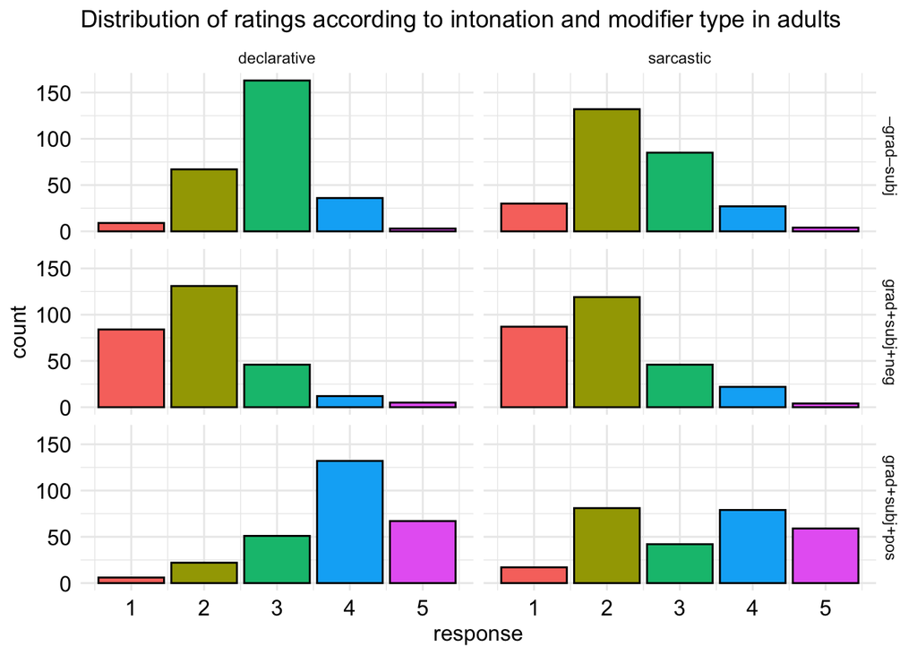

| intonation | modifier_type | 1 | 2 | 3 | 4 | 5 |
| --- | --- | --- | --- | --- | --- | --- |
| declarative | grad+subj+neg | 0.3021583 | 0.4712230 | 0.1654676 | 0.0431655 | 0.0179856 |
| declarative | grad+subj+pos | 0.0215827 | 0.0791367 | 0.1834532 | 0.4748201 | 0.2410072 |
| declarative | –grad–subj | 0.0323741 | 0.2410072 | 0.5863309 | 0.1294964 | 0.0107914 |
| sarcastic | grad+subj+neg | 0.3129496 | 0.4280576 | 0.1654676 | 0.0791367 | 0.0143885 |
| sarcastic | grad+subj+pos | 0.0611511 | 0.2913669 | 0.1510791 | 0.2841727 | 0.2122302 |
| sarcastic | –grad–subj | 0.1079137 | 0.4748201 | 0.3057554 | 0.0971223 | 0.0143885 |

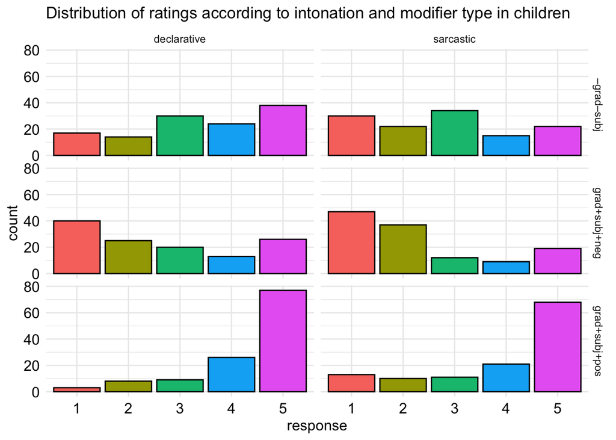

**Adult model for nice and modifier type only**

| Parameter | Median | Mean | MAP | CI | CI_low | CI_high | pd | ps | Rhat | ESS |
| --- | --- | --- | --- | --- | --- | --- | --- | --- | --- | --- |
| b_Intercept[1] | -2.625 | -2.621 | -2.631 | 0.95 | -3.265 | -2.002 | 1.000 | 1.00 | 1.001 | 803.784 |
| b_Intercept[2] | -0.126 | -0.120 | -0.198 | 0.95 | -0.738 | 0.478 | 0.662 | 0.43 | 1.002 | 785.861 |
| b_Intercept[3] | 1.633 | 1.637 | 1.633 | 0.95 | 1.030 | 2.245 | 1.000 | 1.00 | 1.001 | 810.098 |
| b_Intercept[4] | 3.635 | 3.642 | 3.597 | 0.95 | 3.013 | 4.277 | 1.000 | 1.00 | 1.000 | 836.917 |
| b_modifier_typegradPsubjPneg | -1.596 | -1.603 | -1.541 | 0.95 | -2.485 | -0.750 | 1.000 | 1.00 | 1.003 | 692.469 |
| b_modifier_typegradPsubjPpos | 1.926 | 1.915 | 1.964 | 0.95 | 1.069 | 2.707 | 1.000 | 1.00 | 1.001 | 799.883 |

**Child model for nice and modifier type only**

| Parameter | Median | Mean | MAP | CI | CI_low | CI_high | pd | ps | Rhat | ESS |
| --- | --- | --- | --- | --- | --- | --- | --- | --- | --- | --- |
| b_Intercept[1] | -1.874 | -1.879 | -1.859 | 0.95 | -2.551 | -1.247 | 1.000 | 1.000 | 1.004 | 852.019 |
| b_Intercept[2] | -0.694 | -0.698 | -0.694 | 0.95 | -1.337 | -0.074 | 0.984 | 0.949 | 1.003 | 802.470 |
| b_Intercept[3] | 0.338 | 0.334 | 0.363 | 0.95 | -0.313 | 0.959 | 0.851 | 0.680 | 1.002 | 825.562 |
| b_Intercept[4] | 1.315 | 1.312 | 1.348 | 0.95 | 0.671 | 1.975 | 1.000 | 1.000 | 1.002 | 824.672 |
| b_modifier_typegradPsubjPneg | -0.973 | -0.976 | -0.961 | 0.95 | -1.714 | -0.251 | 0.996 | 0.984 | 1.000 | 1245.165 |
| b_modifier_typegradPsubjPpos | 1.808 | 1.809 | 1.776 | 0.95 | 1.074 | 2.542 | 1.000 | 1.000 | 1.001 | 1304.795 |

**Comparison model for nice and modifier type only**

| Parameter | Median | Mean | MAP | CI | CI_low | CI_high | pd | ps | Rhat | ESS |
| --- | --- | --- | --- | --- | --- | --- | --- | --- | --- | --- |
| b_Intercept[1] | -2.164 | -2.156 | -2.209 | 0.95 | -2.743 | -1.561 | 1.000 | 1.000 | 1.011 | 601.013 |
| b_Intercept[2] | -0.118 | -0.111 | -0.155 | 0.95 | -0.669 | 0.467 | 0.655 | 0.413 | 1.011 | 584.064 |
| b_Intercept[3] | 1.385 | 1.395 | 1.368 | 0.95 | 0.834 | 1.979 | 1.000 | 1.000 | 1.010 | 617.607 |
| b_Intercept[4] | 2.904 | 2.914 | 2.872 | 0.95 | 2.344 | 3.507 | 1.000 | 1.000 | 1.010 | 646.288 |
| b_modifier_typegradPsubjPneg | -1.376 | -1.383 | -1.330 | 0.95 | -2.120 | -0.590 | 1.000 | 1.000 | 1.010 | 695.116 |
| b_modifier_typegradPsubjPpos | 1.547 | 1.564 | 1.499 | 0.95 | 0.841 | 2.340 | 1.000 | 1.000 | 1.007 | 664.522 |
| b_groupchildren | 0.872 | 0.875 | 0.853 | 0.95 | 0.449 | 1.304 | 1.000 | 0.999 | 1.007 | 1102.107 |
| b_modifier_typegradPsubjPneg:groupchildren | -0.005 | 0.001 | -0.023 | 0.95 | -0.419 | 0.432 | 0.508 | 0.198 | 1.001 | 2477.055 |
| b_modifier_typegradPsubjPpos:groupchildren | 0.736 | 0.733 | 0.752 | 0.95 | 0.290 | 1.189 | 0.999 | 0.994 | 1.000 | 2714.766 |

**Adult model with intonation and modifier type**

| Parameter | Median | Mean | MAP | CI | CI_low | CI_high | pd | ps | Rhat | ESS |
| --- | --- | --- | --- | --- | --- | --- | --- | --- | --- | --- |
| b_Intercept[1] | -3.190 | -3.192 | -3.185 | 0.95 | -3.861 | -2.530 | 1.000 | 1.000 | 1.004 | 757.745 |
| b_Intercept[2] | -0.595 | -0.601 | -0.554 | 0.95 | -1.243 | 0.031 | 0.964 | 0.900 | 1.004 | 727.596 |
| b_Intercept[3] | 1.259 | 1.261 | 1.239 | 0.95 | 0.597 | 1.908 | 1.000 | 1.000 | 1.004 | 734.036 |
| b_Intercept[4] | 3.319 | 3.326 | 3.229 | 0.95 | 2.621 | 3.997 | 1.000 | 1.000 | 1.004 | 771.654 |
| b_intonationsarcastic | -0.992 | -0.993 | -0.988 | 0.95 | -1.307 | -0.680 | 1.000 | 1.000 | 1.001 | 1802.079 |
| b_modifier_typegradPsubjPneg | -2.097 | -2.112 | -2.025 | 0.95 | -3.063 | -1.265 | 1.000 | 1.000 | 1.007 | 688.615 |
| b_modifier_typegradPsubjPpos | 2.091 | 2.087 | 2.100 | 0.95 | 1.184 | 2.980 | 1.000 | 1.000 | 1.007 | 828.088 |
| b_intonationsarcastic:modifier_typegradPsubjPneg | 0.961 | 0.962 | 0.955 | 0.95 | 0.502 | 1.416 | 1.000 | 0.999 | 1.001 | 2035.242 |
| b_intonationsarcastic:modifier_typegradPsubjPpos | -0.210 | -0.204 | -0.250 | 0.95 | -0.665 | 0.262 | 0.816 | 0.550 | 1.001 | 2365.010 |

**Child model with intonation and modifier type**

| Parameter | Median | Mean | MAP | CI | CI_low | CI_high | pd | ps | Rhat | ESS |
| --- | --- | --- | --- | --- | --- | --- | --- | --- | --- | --- |
| b_Intercept[1] | -2.409 | -2.410 | -2.395 | 0.95 | -3.152 | -1.684 | 1.000 | 1.000 | 1.002 | 1612.205 |
| b_Intercept[2] | -1.192 | -1.192 | -1.200 | 0.95 | -1.914 | -0.476 | 0.998 | 0.997 | 1.002 | 1550.391 |
| b_Intercept[3] | -0.115 | -0.118 | -0.065 | 0.95 | -0.823 | 0.586 | 0.631 | 0.430 | 1.002 | 1535.845 |
| b_Intercept[4] | 0.892 | 0.890 | 0.897 | 0.95 | 0.187 | 1.601 | 0.992 | 0.976 | 1.002 | 1587.796 |
| b_intonationsarcastic | -0.895 | -0.900 | -0.862 | 0.95 | -1.364 | -0.442 | 1.000 | 1.000 | 1.000 | 3406.791 |
| b_modifier_typegradPsubjPneg | -1.148 | -1.145 | -1.154 | 0.95 | -1.971 | -0.281 | 0.993 | 0.986 | 1.000 | 2136.459 |
| b_modifier_typegradPsubjPpos | 1.726 | 1.733 | 1.606 | 0.95 | 0.872 | 2.629 | 1.000 | 0.999 | 1.000 | 1830.429 |
| b_intonationsarcastic:modifier_typegradPsubjPneg | 0.284 | 0.289 | 0.255 | 0.95 | -0.364 | 0.964 | 0.802 | 0.628 | 1.000 | 4097.378 |
| b_intonationsarcastic:modifier_typegradPsubjPpos | 0.247 | 0.249 | 0.235 | 0.95 | -0.473 | 0.973 | 0.754 | 0.577 | 1.000 | 4026.976 |